# Smart Device Usage Data

2026-05-15

## Introduction

**Bellabeat** is a high-tech manufacturer of health-focused smart products for women. Collecting data on activity, sleep, stress, and reproductive health has allowed Bellabeat to empower women with knowledge about their own health and habits. Although Bellabeat has been successful as a small company, it aims to become a larger player in the global smart device market.

## Ask

Bellabeat’s executive team has asked the marketing analytics team to analyze smart device usage data in order to identify trends in consumer behavior. Then, using this information, the team is to provide high-level recommendations for how these trends can transform Bellabeat’s marketing strategy.

The product being focused on is the **Leaf**; Bellabeat’s classic wellness tracker can be worn as a bracelet, necklace, or clip. The Leaf tracker connects to the Bellabeat app to track activity, sleep, and stress.

#### 1. What are some trends in smart device usage?

#### 2. How could these trends apply to Bellabeat customers?

#### 3. How could these trends help influence Bellabeat marketing strategy?

## Prepare

The Fitbit Fitness Tracker dataset from [Kaggle](https://www.kaggle.com/datasets/arashnic/fitbit) was selected for this analysis. The dataset contains smart device usage information, including daily activity, sleep, and calorie tracking data from Fitbit users.

This analysis primarily focuses on the daily activity and sleep datasets, which contain information about user steps, calories burned, activity intensity, and sleep tracking habits.

The dataset contains data from only 30 Fitbit users, which limits how broadly the findings can be generalized. Additionally, the dataset was collected in 2016 and may not fully represent current smart device usage trends.

## Process

Tools used throughout this analysis included R, RStudio, tidyverse, ggplot2, janitor, skimr, and lubridate. The datasets were checked for duplicate records and missing values before analysis.

```
## [1] 0
```

```
## [1] 0
```

```
## [1] 0
```

```
## [1] 525
```

No missing values were identified. The duplicate rows in the minute sleep dataset were inspected to verify whether they represented true duplicate observations.

```
## [1] 0
```

```r
minute_sleep <- minute_sleep %>%
  mutate(date = parse_date_time(date, orders = "mdy HMS p"))
```

Additional cleaning steps may be performed as needed throughout the analysis process.

## Analyze

### Exploring Daily Activity Data

The dataset was explored using summary statistics and data inspection functions to identify patterns and trends in user activity behavior.

Initial observations suggest that users spend a significant amount of time sedentary, with an average of nearly 16.5 sedentary hours per day. Additionally, the average daily step count is approximately 6,500 steps, which is below the commonly recommended benchmark of 10,000 daily steps. The median value for VeryActiveMinutes is 0, indicating that many users recorded little to no high-intensity activity. Overall, the data appears to skew toward sedentary and light activity behavior.

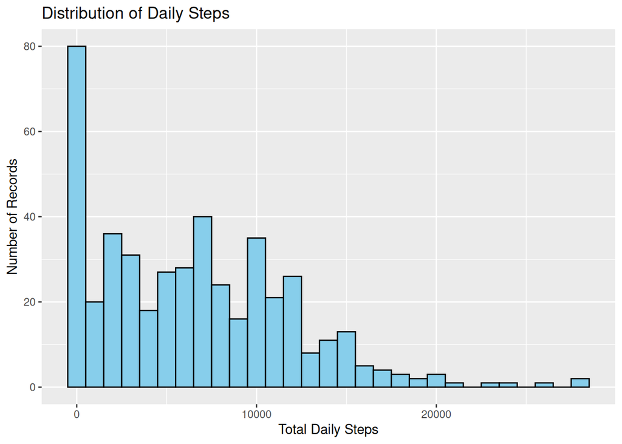

```r
ggplot(daily_activity, aes(x = TotalSteps)) +
  geom_histogram(binwidth = 1000, fill = "skyblue", color = "black") +
  labs(
    title = "Distribution of Daily Steps",
    x = "Total Daily Steps",
    y = "Number of Records"
  )
```

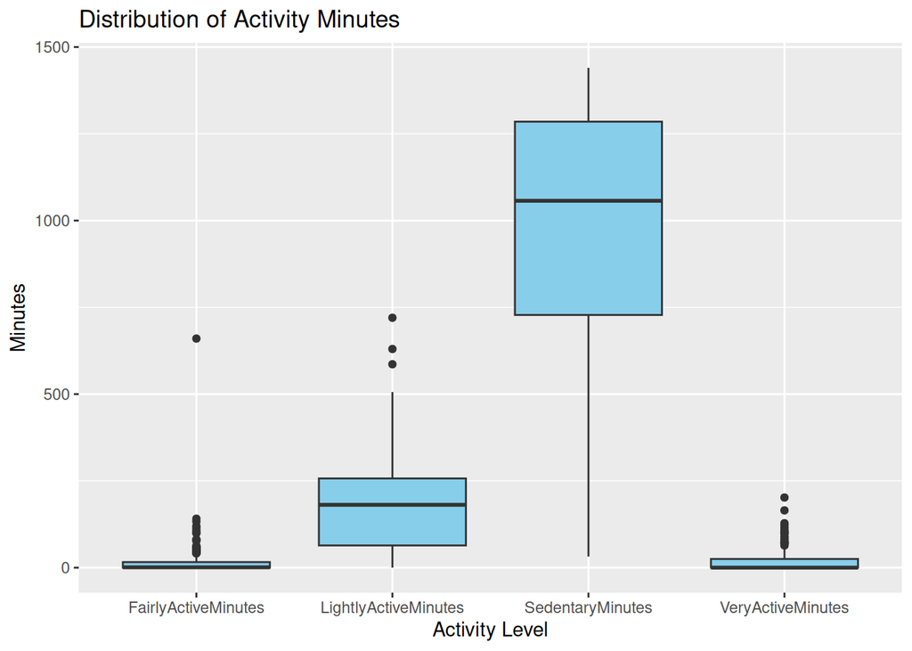

```r
activity_minutes <- daily_activity %>%
  select(VeryActiveMinutes,
         FairlyActiveMinutes,
         LightlyActiveMinutes,
         SedentaryMinutes) %>%
  pivot_longer(cols = everything(),
               names_to = "ActivityLevel",
               values_to = "Minutes")

ggplot(activity_minutes, aes(x = ActivityLevel, y = Minutes)) +
  geom_boxplot(fill = "skyblue") +
  labs(
    title = "Distribution of Activity Minutes",
    x = "Activity Level",
    y = "Minutes"
  )
```

The distribution of activity minutes shows that most users spend a significant amount of time sedentary, while light activity is much more common than moderate or very active exercise. These trends may suggest an opportunity for Bellabeat to encourage users to engage in more consistent physical activity through reminders, activity tracking, and wellness-focused notifications.

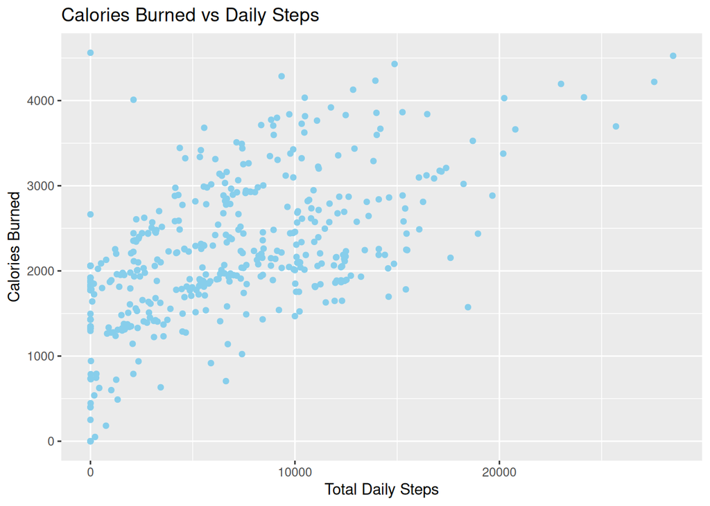

```r
ggplot(daily_activity, aes(x = TotalSteps, y = Calories)) +
  geom_point(color = "skyblue") +
  labs(
    title = "Calories Burned vs Daily Steps",
    x = "Total Daily Steps",
    y = "Calories Burned"
  )
```

The scatterplot shows a clear positive relationship between daily steps and calories burned. In general, users who recorded more daily steps also burned more calories. This relationship reinforces the value of activity tracking and may support Bellabeat’s goal of encouraging users to build more active wellness habits.

### Exploring Sleep Data

The minute-level sleep dataset was summarized into daily sleep totals in order to simplify analysis and identify broader sleep behavior patterns.

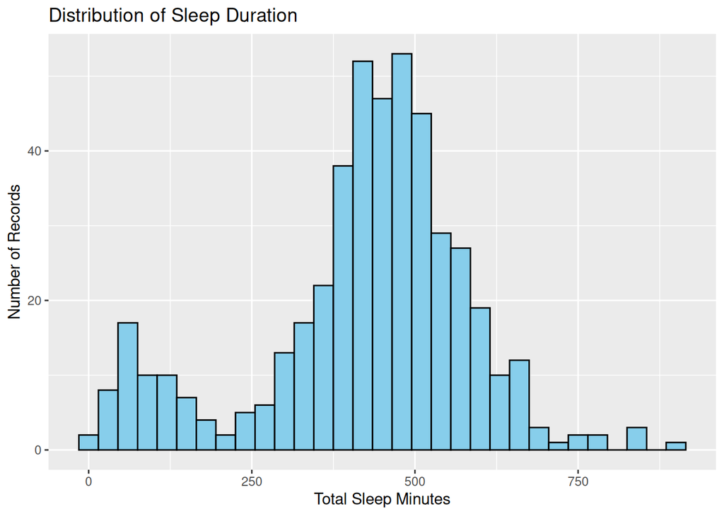

```r
ggplot(sleep_daily, aes(x = TotalSleepMinutes)) +
  geom_histogram(binwidth = 30, fill = "skyblue", color = "black") +
  labs(
    title = "Distribution of Sleep Duration",
    x = "Total Sleep Minutes",
    y = "Number of Records"
  )
```

The distribution of sleep duration suggests that many users recorded sleep durations close to the recommended 8 hours per night. However, a noticeable portion of records show very low sleep durations. This may indicate inconsistent smart device usage during sleep, including users not regularly wearing their device to bed or interruptions in sleep tracking.

### Relationships Between Metrics

Sleep and activity data was merged and observed.

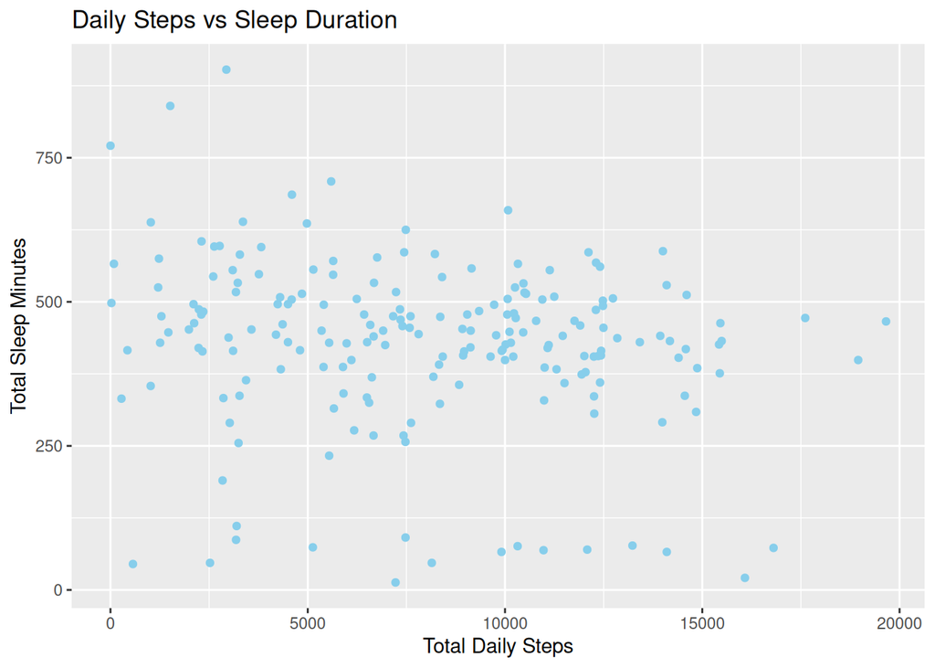

```r
sleep_activity <- daily_activity %>%
  inner_join(
    sleep_daily,
    by = c("Id" = "Id", "ActivityDate" = "Date")
  )

ggplot(sleep_activity, aes(x = TotalSteps, y = TotalSleepMinutes)) +
  geom_point(color = "skyblue") +
  labs(
    title = "Daily Steps vs Sleep Duration",
    x = "Total Daily Steps",
    y = "Total Sleep Minutes"
  )
```

The relationship between daily steps and total sleep minutes appears relatively weak, with no strong correlation visible in the data. This suggests that higher daily activity levels do not necessarily correspond with longer sleep durations among users in this dataset.

## Share

Several important trends were identified throughout the analysis of smart device usage behavior:

- Many users recorded high sedentary time, averaging nearly 16.5 sedentary hours per day.
- Light activity was significantly more common than moderate or high-intensity exercise.
- Average daily step counts were below the commonly recommended benchmark of 10,000 steps.
- A positive relationship was observed between daily steps and calories burned.
- Sleep duration varied considerably between users, with some users recording very low sleep durations.
- Some records suggested inconsistent smart device usage, including periods where users may not have regularly worn their devices.
- Little correlation was observed between daily steps and sleep duration.

## Act

Based on the analysis, several recommendations can be made to help support Bellabeat’s marketing and user engagement strategies.

1. Encourage consistent movement through reminders and wellness notifications. The analysis showed that many users spent a significant amount of time sedentary, while light activity was much more common than intense exercise. Bellabeat could encourage healthier habits by implementing reminders to move throughout the day and promoting achievable activity goals.
2. Promote activity tracking as part of overall wellness improvement. A positive relationship was observed between daily steps and calories burned, reinforcing the value of activity tracking. Bellabeat marketing campaigns could emphasize how consistent daily movement contributes to broader wellness benefits.
3. Expand sleep-focused wellness features and engagement. Sleep duration varied considerably between users, and some users appeared to use their devices inconsistently during sleep tracking. Bellabeat could encourage better sleep tracking habits through sleep reminders, bedtime notifications, and personalized sleep insights.
4. Focus marketing on sustainable and realistic wellness habits. The data suggests that many users participate more in light activity than high-intensity exercise. Bellabeat may benefit from promoting wellness habits that feel approachable and sustainable rather than focusing only on intense fitness goals.

### Conclusion

Overall, the analysis suggests that Bellabeat has an opportunity to position its products around sustainable wellness habits, daily movement, and personalized health insights. By encouraging consistent engagement through activity and sleep tracking features, Bellabeat may be able to strengthen user retention and support healthier lifestyle behaviors.